# Calculations for Lao PDR NFI cycle 4

# 1 Objective

Add calculation of tree AGB, basal area, distribution per DBH class and propagate to treeplot, plot and forest type. Check also main species at forest type and disaggregate per district and province.

Key steps:

- Load clean data
- Join tables
- Calculate at tree level
- Propagate

# 2 Setup

Prepare the environment with packages, paths, sampling info and ancillary data.

# 3 Load the NFI data

NOTE: Run first the “tree-clean.qmd” document when new data arrive to re-create the harmonized tables. This report assumes the latest data is in the folder ‘data-harmo’.

# 4 Join tables

We add land cover code, names and species names to the tree table

```r
tmp$treeplot_info <- treeplot |>
  select(
    ONA_treeplot_id, treeplot_plot_no, treeplot_no, treeplot_id,
    treeplot_crew_lead, treeplot_lc_class, treeplot_lc_type
    ) |>
  mutate(
    treeplot_lc_class2 = case_when(
      treeplot_lc_class == "16AC" ~ 161,
      treeplot_lc_class == "16EC" ~ 162,
      treeplot_lc_class == "16PN" ~ 163,
      treeplot_lc_class == "16RB" ~ 164,
      treeplot_lc_class == "16TK" ~ 165,
      treeplot_lc_class == "16OTH" ~ 169,
      TRUE ~ as.numeric(treeplot_lc_class)
    )
  )

tree_join <- tree |>
  left_join(tmp$treeplot_info, by = c("ONA_parent_index" = "ONA_treeplot_id")) |>
  left_join(anci$lc, by = c("treeplot_lc_class2" = "lc_class")) |>
  left_join(anci$species_list, by = "tree_species_code")

#table(tree_join$treeplot_lc_class2)
table(tree_join$lc_class_code, useNA = "ifany")
```

```
    B    DD    EG   MCB    MD     O  P_AC  P_EC P_OTH  P_RB  P_TK    RP    RV
  539   307   309   228  6616    18    14    43    29   181    38     4   874
   SR    UC     W  <NA>
   11    11     5   606
```

```r
#table(tree_join$tree_species_scientific_name, useNA = "ifany")
```

# 5 Add tree level calculations

Don’t forget the scale factor

```r
## Need to add correction factor for back transformation of ln-ln model
cf <- 1

tree_calc <- tree_join |>
  mutate(
    tree_dbh_class = floor(tree_dbh / 10 ) * 10,
    tree_dbh_class = if_else(tree_dbh_class >= 100, 100, tree_dbh_class),
    tree_ba = round(pi * (tree_dbh/200)^2, 2),
    tree_agb = case_when(
      lc_class_code == "EG"  ~ cf * 0.3112 * tree_dbh^2.2331,
      lc_class_code == "MD"  ~ cf * 0.523081 * tree_dbh^2,
      lc_class_code == "DD"  ~ cf * 0.2137 * tree_dbh^2.2575,
      lc_class_code == "CF"  ~ cf * 0.1277 * tree_dbh^2.3944,
      lc_class_code == "MCB" ~ cf * 0.1277 * tree_dbh^2.3944,
      lc_class_code == "B"   ~ 0, ## Need to find in literature
      lc_class_code == "RV"  ~ cf * 0.523081 * tree_dbh^2, ## Same as MD
      TRUE ~ NA_real_
    ),
    tree_treeplot_radius = if_else(tree_dbh < 30, 8, 16),
    tree_scale_factor = round(10000 / (pi * tree_treeplot_radius^2), 2)
  )
```

Quick check

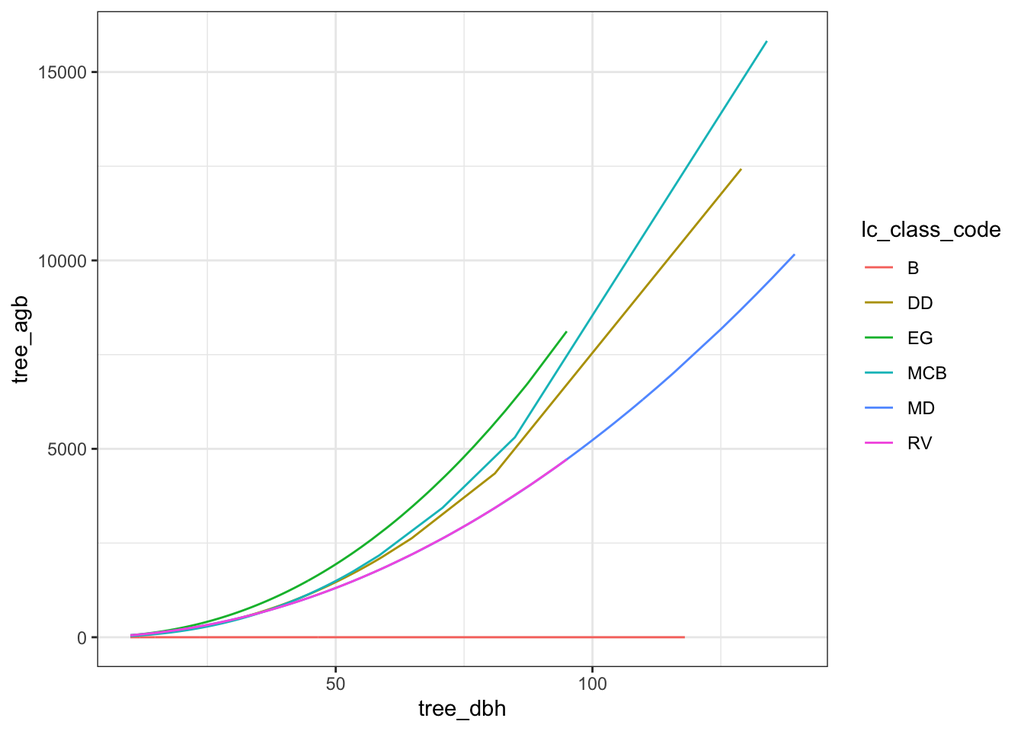

```r
tmp$gg1 <- tree_calc |>
  filter(!is.na(tree_agb)) |>
  ggplot() +
  geom_line(aes(x = tree_dbh, y = tree_agb, color = lc_class_code))

print(tmp$gg1)
```

# 6 Aggregate

## 6.1 Aggregate tree biomass

### 6.1.1 Tree to treeplot

```r
treeplot_agb <- tree_calc |>
  filter(!is.na(treeplot_lc_class)) |>
  group_by(treeplot_id) |>
  summarise(
    count_tree = n(),
    count_ha = sum(tree_scale_factor),
    treeplot_ba = sum(tree_ba * tree_scale_factor),
    treeplot_agb = sum(tree_agb * tree_scale_factor / 1000),
    .groups = "drop"
  )
```

Quick check

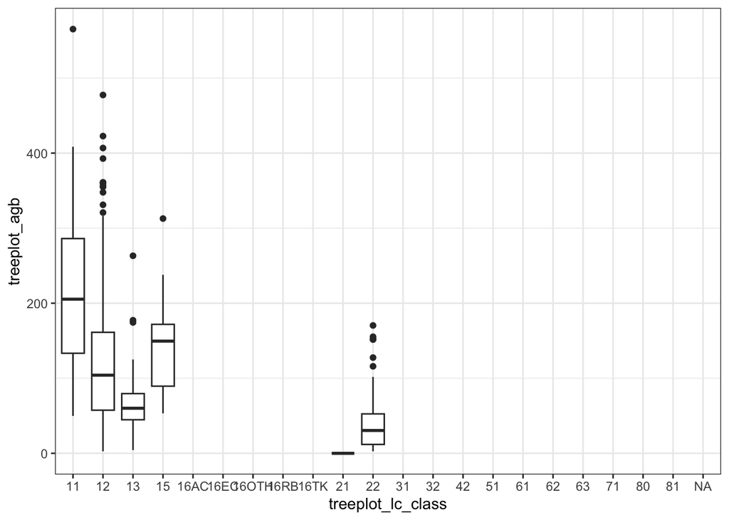

```r
tmp$gg2 <- treeplot_agb |>
  full_join(treeplot, by = c("treeplot_id")) |>
  ggplot() +
  geom_boxplot(aes(x = treeplot_lc_class, y = treeplot_agb))

print(tmp$gg2)
```

We have AGB (ton/ha) at treeplot level, we can add BGB based on AGB values and land cover classes and calculate treeplot level Carbon.

```r
treeplot_final <- treeplot_agb |>
  full_join(treeplot, by = "treeplot_id") |>
  mutate(
    treeplot_lc_class2 = case_when(
      treeplot_lc_class == "16AC" ~ 161,
      treeplot_lc_class == "16EC" ~ 162,
      treeplot_lc_class == "16PN" ~ 163,
      treeplot_lc_class == "16RB" ~ 164,
      treeplot_lc_class == "16TK" ~ 165,
      treeplot_lc_class == "16OTH" ~ 169,
      TRUE ~ as.numeric(treeplot_lc_class)
    )
  ) |>
  left_join(anci$lc, by = c("treeplot_lc_class2" = "lc_class")) |>
  mutate(
    treeplot_rs = case_when(
      lc_class_code == "CF" & treeplot_agb <  50 ~ 0.46,
      lc_class_code == "CF" & treeplot_agb <= 150 ~ 0.32,
      lc_class_code == "CF" & treeplot_agb >  150 ~ 0.23,
      lc_class_code != "CF" & treeplot_agb <  125 ~ 0.2,
      lc_class_code != "CF" & treeplot_agb >= 125 ~ 0.24,
    ),
    treeplot_bgb = treeplot_agb * treeplot_rs,
    treeplot_carbon = round(treeplot_agb * (1 + treeplot_rs), 3),
    treeplot_carbon = case_when(
      lc_class_code %in% c("U", "BR", "O", "W") ~ 0,
      lc_class_code %in% c("UC", "RP", "OA", "AP") ~ 4.9,
      lc_class_code %in% c("SA", "SR", "G", "SW") ~ 4.9,
      TRUE ~ treeplot_carbon
    )
  )
```

Check, amount of Carbon per land cover class

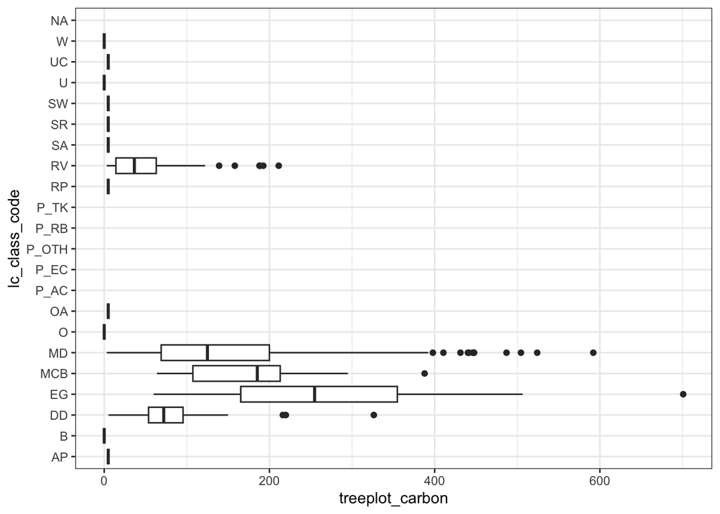

```r
tmp$check <- treeplot_final |>
  ggplot(aes(x = lc_class_code, y = treeplot_carbon)) +
  geom_boxplot() +
  coord_flip()

print(tmp$check)
```

### 6.1.2 Treeplot to plot

Approach 1 the land cover of each plot is the and cover of the treeplot A

```r
tmp$plot_lc <- treeplot_final |>
  filter(treeplot_no == "A") |>
  select(
    plot_no = treeplot_plot_no,
    treeplot_lc_class2, treeplot_coord_lat, treeplot_coord_lon, treeplot_crew_lead
    ) |>
  rename_with(.cols = starts_with("treeplot_"), str_replace, pattern = "treeplot_", replacement = "plot_")

nrow(tmp$plot_lc)
```

```
[1] 330
```

```r
length(unique(treeplot_final$treeplot_plot_no))
```

```
[1] 338
```

Get the plot level carbon stock

```r
plot_c1 <- treeplot_final |>
  group_by(treeplot_plot_no) |>
  summarise(
    treeplot_count = n(),
    plot_c1 = mean(treeplot_carbon, na.rm = T),
    plot_c1_sd = sd(treeplot_carbon, na.rm = T)
  ) |>
  left_join(tmp$plot_lc, by = c("treeplot_plot_no" = "plot_no"))


plot_c1
```

```
# A tibble: 338 × 8
   treeplot_plot_no treeplot_count plot_c1 plot_c1_sd plot_lc_class2
              <dbl>          <int>   <dbl>      <dbl>          <dbl>
 1               12              4   109.        33.7             12
 2               14              4   155.        47.9             12
 3               17              4   126.        81.9             12
 4               18              4   159.       142.              12
 5               21              4   124.        91.8             12
 6               22              4   191.        98.9             12
 7               23              4    38.6       24.6             13
 8               24              3   234.       143.              12
 9               25              4    78.1       12.3             13
10               27              4   138.        72.8             12
# ℹ 328 more rows
# ℹ 3 more variables: plot_coord_lat <dbl>, plot_coord_lon <dbl>,
#   plot_crew_lead <dbl>
```

To add number of TP with the dominant lc

MAP!

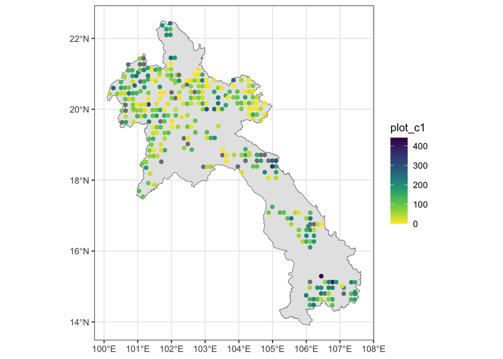

```r
tmp$gg_map <- plot_c1 |>
  filter(!is.na(plot_coord_lon), !is.na(plot_coord_lat)) |>
  st_as_sf(coords = c("plot_coord_lon", "plot_coord_lat"), crs = 4326) |>
  ggplot() +
  geom_sf(data = anci$sf_country) +
  geom_sf(aes(color = plot_c1)) +
  scale_color_viridis_c(direction = -1)
tmp$gg_map
```

Now forest carbon stock

```r
forest_c1 <- plot_c1 |>
  left_join(anci$lc, by = c("plot_lc_class2" = "lc_class")) |>
  group_by(lc_class_code, lc_name, lc_name_lao) |>
  summarise(
    plot_count = n(),
    mean_c1 = mean(plot_c1, na.rm = T),
    sd_c1 = sd(plot_c1, na.rm = T),
    .groups = "drop"
  )

forest_c1
```

```
# A tibble: 16 × 6
   lc_class_code lc_name                    lc_name_lao plot_count mean_c1 sd_c1
   <chr>         <chr>                      <chr>            <int>   <dbl> <dbl>
 1 AP            Agriculture Plantation     ພື້ນທີ່ປູກພືດກະສິ…          1    4.9   NA
 2 B             Bamboo                     ປ່າໄມ້ປ່ອງ (B)         35   18.5   26.8
 3 DD            Dry Dipterocarp            ປ່າໂຄກ (DD)          12   81.5   47.7
 4 EG            Evergreen Forest           ປ່າດົງດິບ (EG)          6  277.   112.
 5 MCB           Mixed Coniferous Broadlea… ປ່າໃບເຂັມປະສົ…          4  185.    63.6
 6 MD            Mixed Deciduous Forest     ປ່າປະສົມ (ປ່າ…        163  133.    68.7
 7 O             Other                      ດິນອື່ນໆ (O)            2    9.92  14.0
 8 OA            Other Agriculture          ກະສິກໍາອື່ນໆ (…          1    4.9   NA
 9 P_EC          Eucalyptus                 ຕົ້ນວິກ                 3  NaN     NA
10 P_OTH         Other                      ອື່ນໆ                  1  NaN     NA
11 P_RB          Rubber                     ຕົ້ນຢາງພາລາ            8   15.6   22.1
12 RP            Rice Paddy                 ທົ່ງນາ (RP)            1    3.27  NA
13 RV            Regenerating Vegetation    ປ່າເລົ່າ / ປ່າ…         61   53.5   43.8
14 UC            Upland Agriculture         ກະສິກໍາ ເຂດເ…         16   23.0   27.0
15 W             Water                      ນໍ້າ / ອ່າງນໍ້າ…          2   19.4   27.5
16 <NA>          <NA>                       <NA>                22  137.   104.
```

Graph

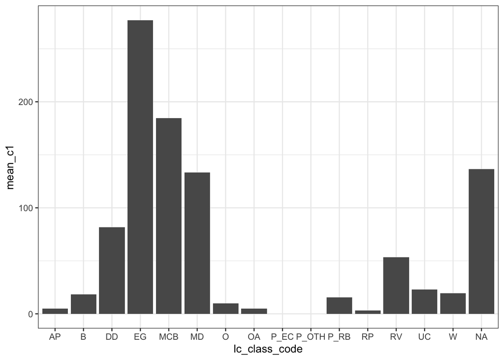

```r
ggplot(forest_c1) +
  geom_col(aes(x = lc_class_code, y = mean_c1))
```

To add:

- number of treeplot with dominant LC
- number of accessible treeplot